# Analiza1 — kopia

```python
import pandas as pd
import matplotlib.pyplot as plt
import seaborn as sns
import numpy as np
from collections import Counter
import re
import nltk
```

Analiza danych dotyczących mieszkań na wynajem wystawionych na niemieckim serwisie ogłoszeniowym w okresie wrzesień 2018 - luty 2020

Dane zostały pobrane z serwisu Kaggle - [link](https://www.kaggle.com/datasets/corrieaar/apartment-rental-offers-in-germany).

1. Wprowadzenie

Rozpocznijmy od zobaczenia DataFrame'a.

```python
df = pd.read_csv(r"C:\Users\rafkr\Downloads\archive (1)\immo_data.csv")
```

```python
df
```

|  | regio1 | serviceCharge | heatingType | telekomTvOffer | telekomHybridUploadSpeed | newlyConst | balcony | picturecount | pricetrend | telekomUploadSpeed | ... | regio2 | regio3 | description | facilities | heatingCosts | energyEfficiencyClass | lastRefurbish | electricityBasePrice | electricityKwhPrice | date |
| --- | --- | --- | --- | --- | --- | --- | --- | --- | --- | --- | --- | --- | --- | --- | --- | --- | --- | --- | --- | --- | --- |
| 0 | Nordrhein_Westfalen | 245.00 | central_heating | ONE_YEAR_FREE | NaN | False | False | 6 | 4.62 | 10.0 | ... | Dortmund | Schüren | Die ebenerdig zu erreichende Erdgeschosswohnun... | Die Wohnung ist mit Laminat ausgelegt. Das Bad... | NaN | NaN | NaN | NaN | NaN | May19 |
| 1 | Rheinland_Pfalz | 134.00 | self_contained_central_heating | ONE_YEAR_FREE | NaN | False | True | 8 | 3.47 | 10.0 | ... | Rhein_Pfalz_Kreis | Böhl_Iggelheim | Alles neu macht der Mai – so kann es auch für ... | NaN | NaN | NaN | 2019.0 | NaN | NaN | May19 |
| 2 | Sachsen | 255.00 | floor_heating | ONE_YEAR_FREE | 10.0 | True | True | 8 | 2.72 | 2.4 | ... | Dresden | Äußere_Neustadt_Antonstadt | Der Neubau entsteht im Herzen der Dresdner Neu... | * 9 m² Balkon\n* Bad mit bodengleicher Dusche,... | NaN | NaN | NaN | NaN | NaN | Oct19 |
| 3 | Sachsen | 58.15 | district_heating | ONE_YEAR_FREE | NaN | False | True | 9 | 1.53 | 40.0 | ... | Mittelsachsen_Kreis | Freiberg | Abseits von Lärm und Abgasen in Ihre neue Wohn... | NaN | 87.23 | NaN | NaN | NaN | NaN | May19 |
| 4 | Bremen | 138.00 | self_contained_central_heating | NaN | NaN | False | True | 19 | 2.46 | NaN | ... | Bremen | Neu_Schwachhausen | Es handelt sich hier um ein saniertes Mehrfami... | Diese Wohnung wurde neu saniert und ist wie fo... | NaN | NaN | NaN | NaN | NaN | Feb20 |
| ... | ... | ... | ... | ... | ... | ... | ... | ... | ... | ... | ... | ... | ... | ... | ... | ... | ... | ... | ... | ... | ... |
| 268845 | Bayern | 90.00 | heat_pump | ONE_YEAR_FREE | NaN | False | True | 0 | 2.74 | 10.0 | ... | Weilheim_Schongau_Kreis | Eberfing | Diese schöne, neuwertige Wohnung im Dachgescho... | Fliesen und Parkett. Sichtbarer Dachstuhl. | NaN | NaN | NaN | NaN | NaN | Feb20 |
| 268846 | Hessen | 220.00 | gas_heating | NaN | NaN | False | True | 12 | 6.49 | NaN | ... | Bergstraße_Kreis | Viernheim | Hier wird eine Wohnung im 2 Familienhaus angeb... | Parkett, Kamin, Badewanne&Dusche\nGroßer Balko... | NaN | NaN | 2015.0 | NaN | NaN | May19 |
| 268847 | Hessen | 220.00 | central_heating | ONE_YEAR_FREE | NaN | False | True | 21 | 2.90 | 40.0 | ... | Limburg_Weilburg_Kreis | Limburg_an_der_Lahn | gemütliche 4-Zimmer-Wohnung im Obergeschoss ei... | Böden: Wohn-/Schlafbereich = Laminat, Küche + ... | NaN | NaN | 2019.0 | NaN | NaN | Feb20 |
| 268848 | Nordrhein_Westfalen | 175.00 | heat_pump | NaN | NaN | True | True | 16 | 4.39 | NaN | ... | Köln | Dellbrück | Neubau Erstbezug, gehobener Standard, alle Ein... | Wände:\nMalervlies, weiß gestrichen alternat... | 40.00 | NO_INFORMATION | 2019.0 | NaN | NaN | May19 |
| 268849 | Hessen | 315.00 | central_heating | NaN | NaN | False | True | 9 | 5.00 | NaN | ... | Frankfurt_am_Main | Sossenheim | Schöne, helle, gut geschnittene und teilmöblie... | Balkon, Keller, Fahrstuhl, Vollbad, Einbauküch... | NaN | NaN | NaN | NaN | NaN | Feb20 |

268850 rows × 49 columns

- bool
- int
- float
- object (string)

```python
df.info()
```

```
<class 'pandas.core.frame.DataFrame'>
RangeIndex: 268850 entries, 0 to 268849
Data columns (total 49 columns):
 #   Column                    Non-Null Count   Dtype
---  ------                    --------------   -----
 0   regio1                    268850 non-null  object
 1   serviceCharge             261941 non-null  float64
 2   heatingType               223994 non-null  object
 3   telekomTvOffer            236231 non-null  object
 4   telekomHybridUploadSpeed  45020 non-null   float64
 5   newlyConst                268850 non-null  bool
 6   balcony                   268850 non-null  bool
 7   picturecount              268850 non-null  int64
 8   pricetrend                267018 non-null  float64
 9   telekomUploadSpeed        235492 non-null  float64
```

[output cut: 41 more lines]

Wywołanie metody describe() spowoduje wyświetlenie podstawowych statystyk dla kolumn liczbowych. Przeglądając te statystyki można zauważyć, że jakość danych nie jest doskonała, na przykład w kolumnie "yearConstructed" mamy absurdalne wartości, takie jak 1000 lub 2090.

```python
df.describe()
```

|  | serviceCharge | telekomHybridUploadSpeed | picturecount | pricetrend | telekomUploadSpeed | totalRent | yearConstructed | scoutId | noParkSpaces | yearConstructedRange | ... | noRooms | thermalChar | floor | numberOfFloors | noRoomsRange | livingSpaceRange | heatingCosts | lastRefurbish | electricityBasePrice | electricityKwhPrice |
| --- | --- | --- | --- | --- | --- | --- | --- | --- | --- | --- | --- | --- | --- | --- | --- | --- | --- | --- | --- | --- | --- |
| count | 261941.000000 | 45020.0 | 268850.000000 | 267018.000000 | 235492.000000 | 2.283330e+05 | 211805.000000 | 2.688500e+05 | 93052.000000 | 211805.000000 | ... | 268850.000000 | 162344.000000 | 217541.000000 | 171118.000000 | 268850.000000 | 268850.000000 | 85518.000000 | 80711.000000 | 46846.000000 | 46846.000000 |
| mean | 151.206113 | 10.0 | 9.791958 | 3.389001 | 28.804928 | 9.013315e+02 | 1966.400590 | 1.069697e+08 | 1.327634 | 3.714544 | ... | 2.641261 | 114.749533 | 2.122405 | 3.572319 | 2.571542 | 3.070790 | 76.990866 | 2013.904536 | 89.113612 | 0.199769 |
| std | 308.295790 | 0.0 | 6.408399 | 1.964874 | 16.337151 | 3.323833e+04 | 46.992207 | 1.250093e+07 | 8.361403 | 2.738134 | ... | 2.633440 | 61.653663 | 3.634934 | 6.375496 | 0.937594 | 1.407127 | 147.716278 | 10.963125 | 5.395805 | 0.009667 |
| min | 0.000000 | 10.0 | 0.000000 | -12.330000 | 1.000000 | 0.000000e+00 | 1000.000000 | 2.887174e+07 | 0.000000 | 1.000000 | ... | 1.000000 | 0.100000 | -1.000000 | 0.000000 | 1.000000 | 1.000000 | 0.000000 | 1015.000000 | 71.430000 | 0.170500 |
| 25% | 95.000000 | 10.0 | 6.000000 | 2.000000 | 10.000000 | 4.698000e+02 | 1950.000000 | 1.066910e+08 | 1.000000 | 1.000000 | ... | 2.000000 | 79.000000 | 1.000000 | 2.000000 | 2.000000 | 2.000000 | 54.000000 | 2012.000000 | 90.760000 | 0.191500 |
| 50% | 135.000000 | 10.0 | 9.000000 | 3.390000 | 40.000000 | 6.500000e+02 | 1973.000000 | 1.111584e+08 | 1.000000 | 3.000000 | ... | 3.000000 | 107.000000 | 2.000000 | 3.000000 | 3.000000 | 3.000000 | 70.000000 | 2017.000000 | 90.760000 | 0.198500 |
| 75% | 190.000000 | 10.0 | 13.000000 | 4.570000 | 40.000000 | 9.850000e+02 | 1996.000000 | 1.137688e+08 | 1.000000 | 5.000000 | ... | 3.000000 | 140.300000 | 3.000000 | 4.000000 | 3.000000 | 4.000000 | 90.000000 | 2019.000000 | 90.760000 | 0.205500 |
| max | 146118.000000 | 10.0 | 121.000000 | 14.920000 | 100.000000 | 1.575154e+07 | 2090.000000 | 1.157117e+08 | 2241.000000 | 9.000000 | ... | 999.990000 | 1996.000000 | 999.000000 | 999.000000 | 5.000000 | 7.000000 | 12613.000000 | 2919.000000 | 90.760000 | 0.227600 |

8 rows × 24 columns

2. Analiza

2.1 Ogłoszenia według daty

Zobaczmy, w którym miesiącu odnotowano najwięcej ogłoszeń.  
Dane zostały zgrupowane według okresu ich zebrania, a następnie zliczyliśmy ilość rekordów dla każdej grupy.  
Aby dane na wykresie zostały wyświetlone w odpowiedniej kolejności, kolumna "date" została zamieniona na kolumnę zawierającą dane kategoryczne, następnie DataFrame został posortowany

```python
dict_year = {'Sep18': 2018,
             'May19': 2019,
            'Oct19': 2019,
           'Feb20': 2020 }
```

```python
df_by_date = df.groupby('date')['regio1'].count().reset_index().rename(columns={'regio1': 'no_of_offers'})
year_order = ["Sep18", "May19", "Oct19", "Feb20"]
df_by_date['date'] = pd.Categorical(df_by_date['date'])
df_by_date['date'] = df_by_date['date'].cat.reorder_categories(year_order)
df_by_date = df_by_date.sort_values(by='date')
```

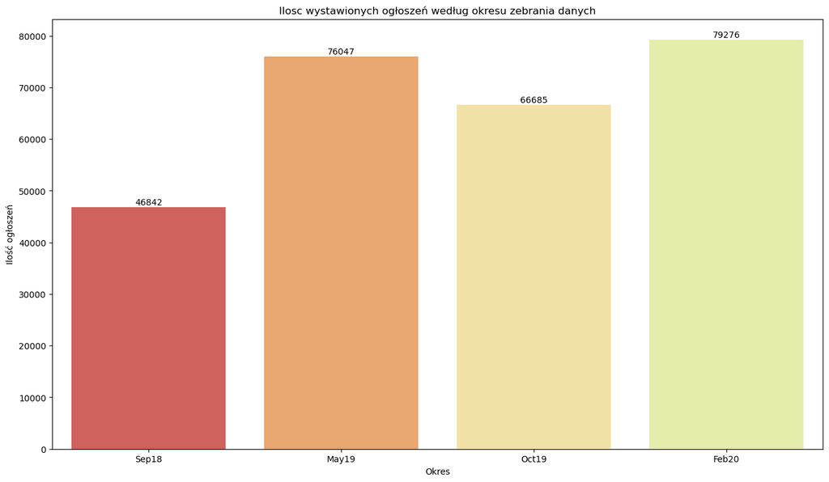

```python
plt.figure(figsize=(16,9))
ax = sns.barplot(data=df_by_date,x='date',y='no_of_offers', palette=sns.color_palette('Spectral'))
ax.bar_label(ax.containers[0])
plt.title('Ilosc wystawionych ogłoszeń według okresu zebrania danych')
plt.xlabel('Okres')
plt.ylabel('Ilość ogłoszeń')
plt.show()
```

2.2 Ogłoszenia według landu

Sprawdźmy, czy któryś obszar terytorium Niemiec zawiera znacznie więcej wystawionych ogłoszeń niż pozostałe  
Wykres informuje, że niemal połowa ogłoszeń pochodzi z tylko dwóch landów: Nadrenia Północna-Westfalia oraz Saksonia

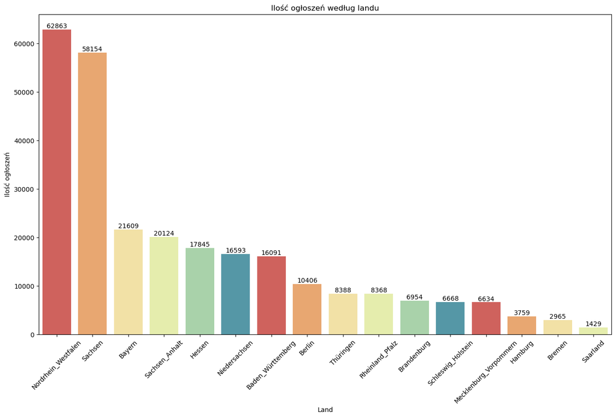

```python
df_per_land = df.groupby('regio1')['picturecount'].count().reset_index().rename(columns={'picturecount': 'Ilosc_ogloszen', 'regio1':'Land'})
df_per_land = df_per_land.sort_values(by='Ilosc_ogloszen', ascending=False)
plt.figure(figsize=(16,9))
ax = sns.barplot(data=df_per_land, x='Land', y='Ilosc_ogloszen', palette=sns.color_palette('Spectral'))
plt.title('Ilość ogłoszeń według landu')
plt.xlabel('Land')
plt.ylabel('Ilość ogłoszeń')
ax.bar_label(ax.containers[0])
plt.xticks(rotation=45)
plt.show()
```

2.3 Ogłoszenia według miasta

Zweryfikujmy, czy dane o ilości ogłoszeń według miasta pokrywają się z danymi per land.  
Ku zdziwieniu, w TOP 3 plasują się dwa miasta z Saksonii oraz stolica. Pierwsze miasto z Nadrenii Północnej-Westfalii znajduje się dopiero na miejscu nr 8, jest to Essen.

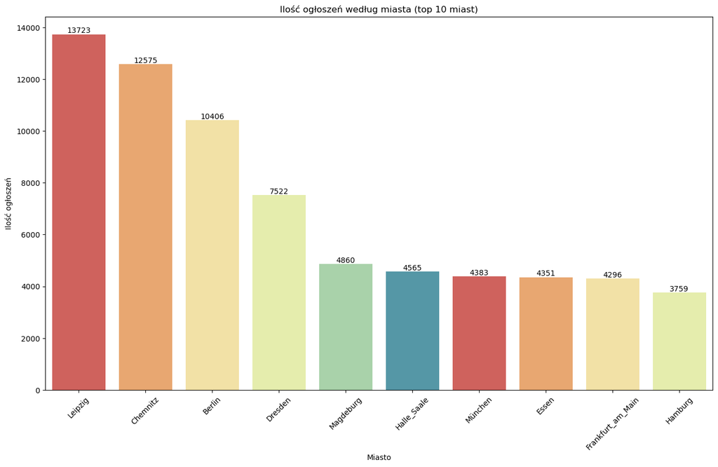

```python
df_per_city = df.groupby('regio2')['picturecount'].count().reset_index().rename(columns={'picturecount': 'Ilosc_ogloszen', 'regio2':'Miasto'}).sort_values(by='Ilosc_ogloszen',ascending=False)
df_per_city = df_per_city.head(10)
plt.figure(figsize=(16,9))
ax = sns.barplot(data=df_per_city, x='Miasto', y='Ilosc_ogloszen', palette=sns.color_palette('Spectral'))
plt.title('Ilość ogłoszeń według miasta (top 10 miast)')
plt.xlabel('Miasto')
plt.ylabel('Ilość ogłoszeń')
ax.bar_label(ax.containers[0])
plt.xticks(rotation=45)
plt.show()
```

2.4 Rok w którym wybudowano budynek

Ze względu na sporą ilość danych, nie ma sensu przedstawiać na wizualizacji każdego roku jako osobnego słupka. Znacznie lepiej będzie pogrupować dane w koszyki, odpowidające kilkuletnim okresom. Ponadto, dane należy zawęzić, gdyż niektóre daty konstrukcji budynków wydają się nieprawdopodobne (rok 1000) lub nawet niemożliwe (rok 2090).  
Korzystając z funkcji pd.qcut() podzieliliśmy dane na 25 koszyków.

```python
df_year = df.groupby(['yearConstructed'])['regio1'].count().reset_index().rename(columns={'regio1': 'ilosc_budynkow'})
df_year2 = df_year[df_year['yearConstructed'].between(1800,2021)]

df_year2['yearConstructed_bins'] = pd.qcut(df_year2['yearConstructed'],q=25)
df_year2['yearConstructed_bins_left'] = df_year2['yearConstructed_bins'].apply(lambda x: round(x.left))
df_year2['yearConstructed_bins_right'] = df_year2['yearConstructed_bins'].apply(lambda x: round(x.right))
```

```python
df_year2['bins'] = '(' + df_year2['yearConstructed_bins_left'].astype(str) +', ' +df_year2['yearConstructed_bins_right'].astype(str) +'>'

df_year2 = df_year2.drop(columns=['yearConstructed_bins', 'yearConstructed_bins_left', 'yearConstructed_bins_right'])
df_year2 = df_year2.groupby(['bins'])['ilosc_budynkow'].sum().reset_index()
```

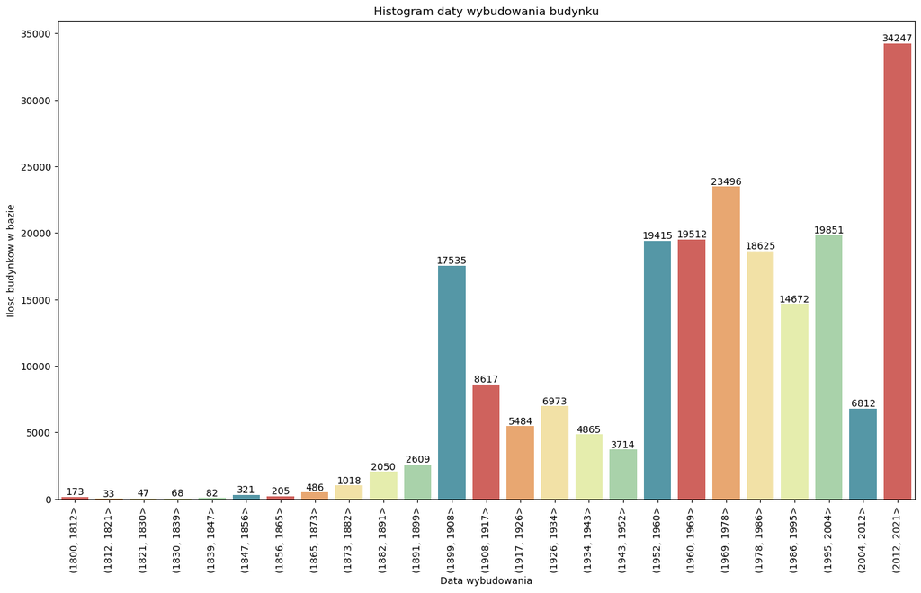

```python
plt.figure(figsize=(16,9))
ax = sns.barplot(data=df_year2,x='bins', y='ilosc_budynkow', palette=sns.color_palette('Spectral'))
plt.title('Histogram daty wybudowania budynku')
plt.xlabel('Data wybudowania')
plt.ylabel('Ilosc budynkow w bazie')
plt.xticks(rotation=90)
plt.bar_label(ax.containers[0])
plt.show()
```

2.5 Czynsz w 10 najczęściej występujących w bazie miastach

Sprawdźmy, jak wyglądają koszty czynszu w miastach najczęściej pojawiających się w bazie. Posłużymy się percentylami, aby zobaczyć jak bardzo "rozstrzelone" są ceny w poszczególnych miastach oraz być w stanie łatwiej porównywać ceny pomiędzy poszczególnymi miastami.

Funkcja percentile została znaleziona w Internecie: [link](https://stackoverflow.com/questions/17578115/pass-percentiles-to-pandas-agg-function)

```python
def percentile(n):
    def percentile_(x):
        return np.percentile(x, n)
    percentile_.__name__ = 'percentile_%s' % n
    return percentile_
```

```python
df_rent = df[~df['totalRent'].isna()]
miasta = df_rent['regio2'].value_counts().head(10).index
```

```python
df_rent2 = df_rent[df_rent['regio2'].isin(miasta)]
df_rent_gr = df_rent2.groupby('regio2')['totalRent'].agg([percentile(10), percentile(20), percentile(50), percentile(75), percentile(90)])
df_rent_gr = df_rent_gr.reset_index()

df_rent_melt = pd.melt(df_rent_gr, id_vars='regio2')
```

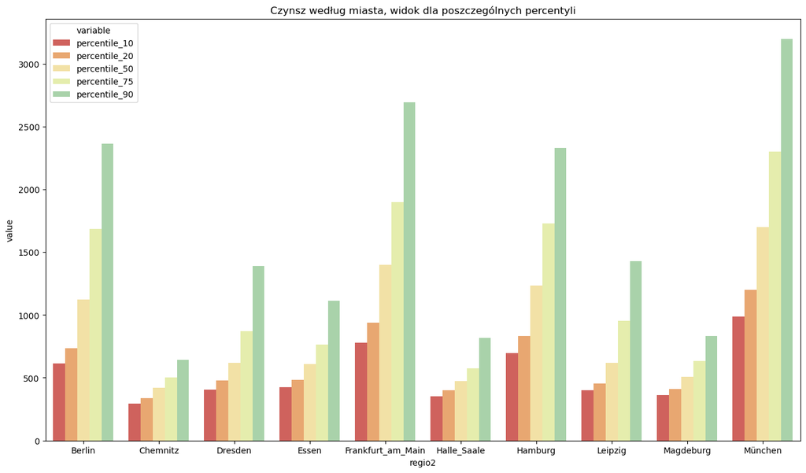

```python
plt.figure(figsize=(16,9))
sns.barplot(data=df_rent_melt, x='regio2',y='value', hue='variable', palette=sns.color_palette('Spectral'))
plt.title('Czynsz według miasta, widok dla poszczególnych percentyli')
plt.show()
```

2.6 Wskaźnik % udziału nowego budownictwa

Proponujemy wskaźnik informujący, w której miejscowości jest największe prawdopodobieństwo na natrafienie na ofertę we współczesnym budownictwie.  
Wyznaczenie wskaźnika polega na wybraniu miast z największą ilością nowych budynków i podzieleniu przez całkowitą ilość budynków na wynajem w tych miejscowościach

```python
df_new = df[df['newlyConst']==True]
top10_new = df_new['regio2'].value_counts().head(10).index

df_new_top10= df_new[df_new['regio2'].isin(top10_new)]
df_top10 = df[df['regio2'].isin(top10_new)]

df_new_top10 = df_new_top10.groupby(['regio2'])['regio1'].count().reset_index().rename(columns={'regio1': 'Ilosc_nowych_na_wynajem'})

df_top10 = df_top10.groupby(['regio2'])['regio1'].count().reset_index().rename(columns={'regio1': 'Calkowita_ilosc_na_wynajem'})
df_new_top10
```

|  | regio2 | Ilosc_nowych_na_wynajem |
| --- | --- | --- |
| 0 | Berlin | 1667 |
| 1 | Dortmund | 182 |
| 2 | Dresden | 960 |
| 3 | Düsseldorf | 290 |
| 4 | Frankfurt_am_Main | 547 |
| 5 | Hamburg | 633 |
| 6 | Köln | 187 |
| 7 | Leipzig | 1044 |
| 8 | München | 865 |
| 9 | Segeberg_Kreis | 190 |

```python
df_top10
```

|  | regio2 | Calkowita_ilosc_na_wynajem |
| --- | --- | --- |
| 0 | Berlin | 10406 |
| 1 | Dortmund | 3137 |
| 2 | Dresden | 7522 |
| 3 | Düsseldorf | 3711 |
| 4 | Frankfurt_am_Main | 4296 |
| 5 | Hamburg | 3759 |
| 6 | Köln | 2709 |
| 7 | Leipzig | 13723 |
| 8 | München | 4383 |
| 9 | Segeberg_Kreis | 667 |

```python
df_new_ratio = df_new_top10.merge(df_top10, how='inner', on='regio2')
df_new_ratio['Wspolczynnik'] = df_new_ratio['Ilosc_nowych_na_wynajem'] / df_new_ratio['Calkowita_ilosc_na_wynajem'] * 100
df_new_ratio['Wspolczynnik'] = round(df_new_ratio['Wspolczynnik'],2)
```

```python
df_new_ratio = df_new_ratio.sort_values(by='Wspolczynnik',ascending=False)
```

```python
df_new_ratio
```

|  | regio2 | Ilosc_nowych_na_wynajem | Calkowita_ilosc_na_wynajem | Wspolczynnik |
| --- | --- | --- | --- | --- |
| 9 | Segeberg_Kreis | 190 | 667 | 28.49 |
| 8 | München | 865 | 4383 | 19.74 |
| 5 | Hamburg | 633 | 3759 | 16.84 |
| 0 | Berlin | 1667 | 10406 | 16.02 |
| 2 | Dresden | 960 | 7522 | 12.76 |
| 4 | Frankfurt_am_Main | 547 | 4296 | 12.73 |
| 3 | Düsseldorf | 290 | 3711 | 7.81 |
| 7 | Leipzig | 1044 | 13723 | 7.61 |
| 6 | Köln | 187 | 2709 | 6.90 |
| 1 | Dortmund | 182 | 3137 | 5.80 |

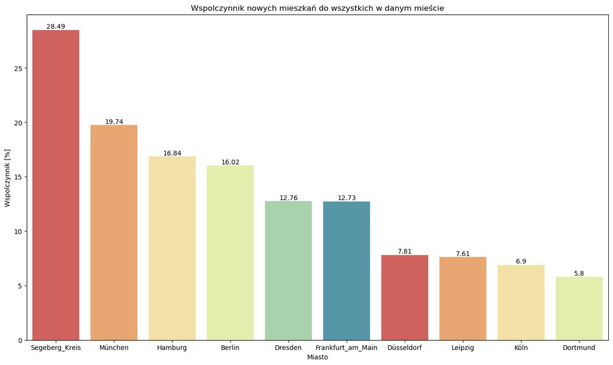

```python
plt.figure(figsize=(16,9))
ax = sns.barplot(data=df_new_ratio, x='regio2',y='Wspolczynnik', palette=sns.color_palette('Spectral'))
plt.title('Wspolczynnik nowych mieszkań do wszystkich w danym mieście')
plt.xlabel('Miasto')
plt.ylabel('Wspolczynnik [%]')
ax.bar_label(ax.containers[0])
plt.show()
```

2.7 Korelacje

Wyznaczmy współczynniki korelacji pomiędzy parami wyselekcjonowanych zmiennych

```python
df_corr = df[['yearConstructed', 'totalRent', 'baseRent', 'livingSpace', 'noRooms']]
df_corr = df_corr.dropna(subset=['yearConstructed', 'totalRent', 'baseRent', 'livingSpace', 'noRooms'])
df_corr = df_corr.astype(int)
```

```python
df_corr
```

|  | yearConstructed | totalRent | baseRent | livingSpace | noRooms |
| --- | --- | --- | --- | --- | --- |
| 0 | 1965 | 840 | 595 | 86 | 4 |
| 2 | 2019 | 1300 | 965 | 83 | 3 |
| 4 | 1950 | 903 | 765 | 84 | 3 |
| 7 | 1959 | 584 | 452 | 60 | 3 |
| 8 | 1970 | 690 | 580 | 53 | 2 |
| ... | ... | ... | ... | ... | ... |
| 268843 | 1930 | 368 | 248 | 55 | 2 |
| 268845 | 2016 | 910 | 820 | 90 | 3 |
| 268846 | 1983 | 1150 | 930 | 115 | 3 |
| 268847 | 1965 | 930 | 650 | 95 | 4 |
| 268848 | 2019 | 1015 | 840 | 70 | 2 |

179048 rows × 5 columns

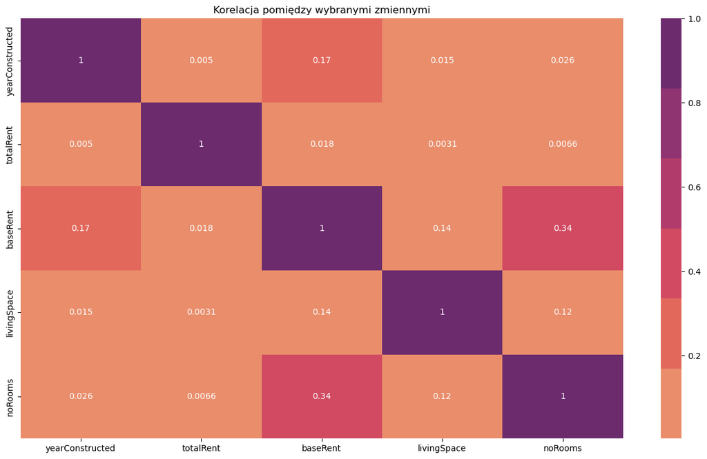

```python
plt.figure(figsize=(16,9))
sns.heatmap(df_corr.corr(), cmap=sns.color_palette('flare') ,annot=True)
plt.title('Korelacja pomiędzy wybranymi zmiennymi')
plt.show()
```

Pomiędzy zmiennymi nie widać wyraźnych korelacji - największa wartość wskaźnika jest pomiędzy ilością pokoi a poziomem czynszu

3. Analiza słów które pojawiają się w opisie mieszkania

W ramach działań "ponadprogramowych" postanowiliśmy zapoznać się z podstawami biblioteki NLTK aby wyznaczyć najczęściej występujące słowa w opisie mieszkań. W celu oczyszczenia danych pozbyliśmy się większości stopwordsów, czyli słów, które nie noszą żadnego konkretnego przekazu oraz sprowadziliśmy słowa do formy podstawowej. Analiza została przeprowadzona na niewielkim wycinku danych, składającym się z 10 tysięcy rekordów.

Wizualizacja została wykonana bazując na artykule z [linka](https://towardsdatascience.com/beyond-the-cloud-4-visualizations-to-use-instead-of-word-cloud-960dd516f215)

```python
stopwords = nltk.corpus.stopwords.words('german')
df_words = df.copy()
df_words = df_words[['description']]

df_words['description2'] = df_words['description'].astype(str)
```

```python
df_subset = df_words.iloc[:10000]
df_subset['description3'] = df_subset['description2'].apply(lambda x: nltk.word_tokenize(x))

porter = nltk.stem.PorterStemmer()
df_subset['description4'] = df_subset['description3'].apply(lambda cell: [porter.stem(x) for x in cell])
stemmed_list = df_subset['description4'].to_list()

stemmed_list_flattened = [item for sublist in stemmed_list for item in sublist]

counted_words = Counter(stemmed_list_flattened)
df_counted = pd.DataFrame.from_dict(counted_words,orient='index').reset_index()
df_counted = df_counted.rename(columns={'index': 'Slowo', 0: 'Ilosc_wystapien'})

df_counted['CzyStopword'] = df_counted['Slowo'].apply(lambda x: 1 if x in stopwords else 0)
df_counted = df_counted[df_counted['CzyStopword']==0].reset_index(drop=True)

df_counted['CzyStopword2'] = df_counted['Slowo'].apply(lambda x: 0 if re.match('[\w]+', x) else 1 )
df_counted = df_counted[df_counted['CzyStopword2']==0].reset_index(drop=True)
df_counted = df_counted.sort_values(by=['Ilosc_wystapien'],ascending=False)
```

```python
n = df_counted['Ilosc_wystapien'].max()
df_counted_top100 = df_counted.iloc[:100]
```

```python
index_list = [[i[0],i[-1]+1] for i in np.array_split(range(100), 5)]
```

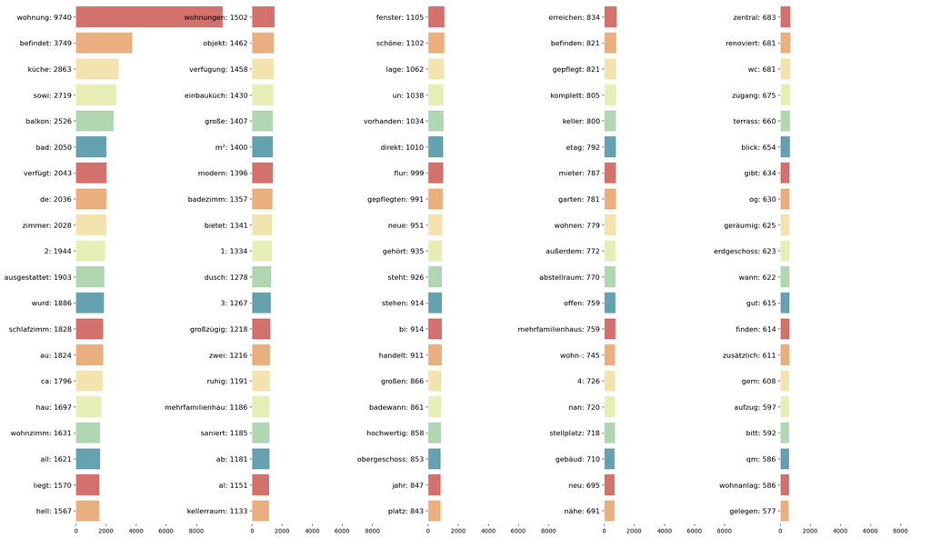

```python
fig, axes = plt.subplots(1,5, figsize=(26,16), facecolor='white', squeeze=False)
for col, idx in zip(range(0,5), index_list):
    df_t = df_counted_top100[idx[0]:idx[-1]]

    label = [w + ': ' + str(n) for w,n in zip(df_t['Slowo'],df_t['Ilosc_wystapien'])]
    #color_l = [color_dict.get(i) for i in df_t['Ilosc_wystapien']]
    x = list(df_t['Ilosc_wystapien'])
    y = list(range(0,20))

    sns.barplot(x = x, y = y, data=df_t, alpha=0.9, orient = 'h',
                ax = axes[0][col],palette=sns.color_palette('Spectral'))

    axes[0][col].set_xlim(0,n+1)                     #set X axis range max
    axes[0][col].set_yticklabels(label, fontsize=12)
    axes[0][col].spines['bottom'].set_color('white')
    axes[0][col].spines['right'].set_color('white')
    axes[0][col].spines['top'].set_color('white')
    axes[0][col].spines['left'].set_color('white')
```